# Extra Credit 1

Dipen Patel

2023-06-06

```r
library(tidyverse)
library(nycflights13)
library(ggridges)
library(maps)
library(mapproj)
library(readxl)
library(janitor)
library(grid)
library(RColorBrewer)
```

### Load dataset

```r
df <- read_csv("working_together_data.csv")
```

## Visualization 1: Heatmap

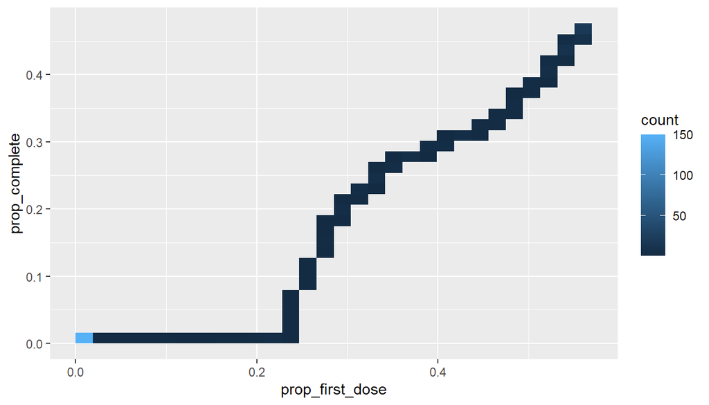

```r
df %>%
  filter(age_group=="12 - 15 Years") %>%
  ggplot(aes(x = prop_first_dose, y=prop_complete))+
  geom_bin2d()
```

## Visualization 2: Violin Plot

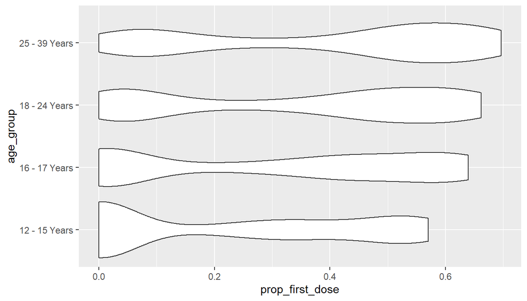

```r
df %>%
  filter(age_group %in% c("12 - 15 Years","16 - 17 Years","18 - 24 Years", "25 - 39 Years")) %>%
  ggplot(aes(y = age_group, x = prop_first_dose))+
  geom_violin()
```

This is a Violin plot to visualize the distribution of selected age categories (“12 - 15 Years”,“16 - 17 Years”,“18 - 24 Years”, “25 - 39 Years”).

## Visualization 3: Ridgeline

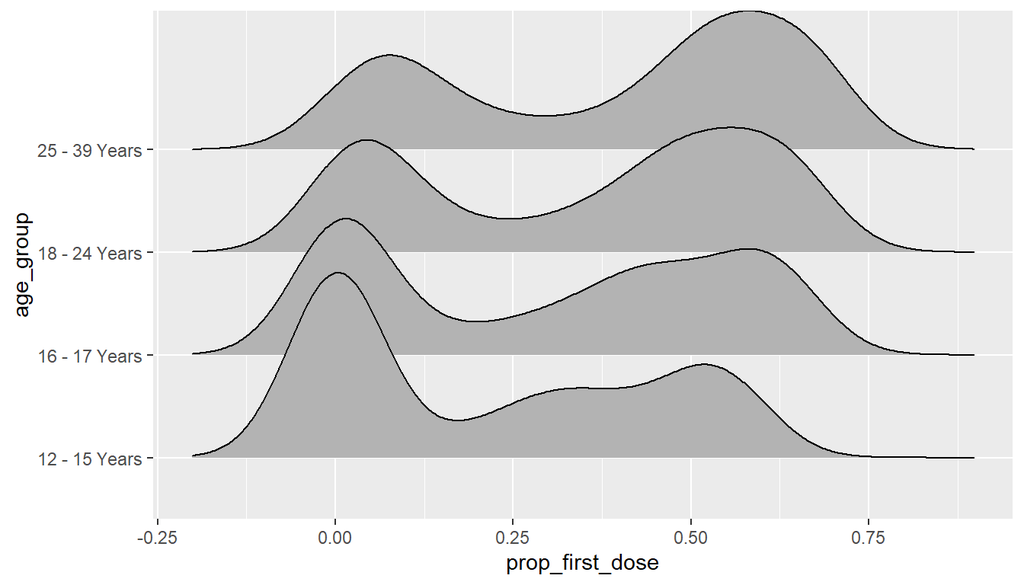

```r
df %>%
  filter(age_group %in% c("12 - 15 Years","16 - 17 Years","18 - 24 Years", "25 - 39 Years")) %>%
  ggplot(aes(y = age_group, x = prop_first_dose))+
  geom_density_ridges()
```

This is a Ridgeline plot to visualize the distribution of selected age categories (“12 - 15 Years”,“16 - 17 Years”,“18 - 24 Years”, “25 - 39 Years”).

## Visualization 4: Density plot

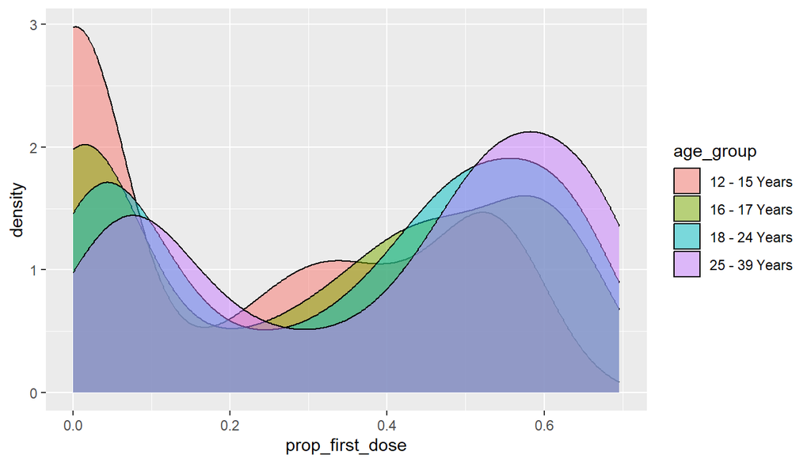

```r
df %>%
  filter(age_group %in% c("12 - 15 Years","16 - 17 Years","18 - 24 Years", "25 - 39 Years")) %>%
  ggplot(aes(x = prop_first_dose, fill=age_group))+
  geom_density(alpha=0.5)
```

This is a density plot to visualize the distribution of selected age categories (“12 - 15 Years”,“16 - 17 Years”,“18 - 24 Years”, “25 - 39 Years”).

## Visualization 5: Donut plot

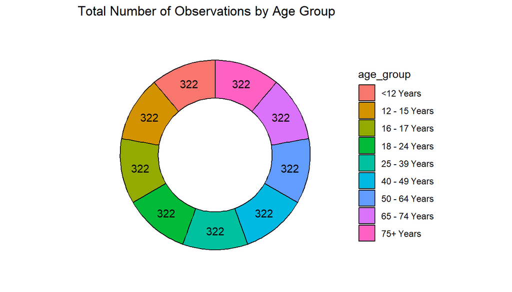

```r
df %>%
  group_by(age_group) %>%
  summarise(n=n()) %>%
  ggplot(aes(x=2, y = n, fill = age_group)) +
  geom_col(color="black") +
  geom_text(aes(label = n),
            position = position_stack(vjust = 0.5)) +
  coord_polar(theta = "y") +
  xlim(c(0.2,  2.8))+
  labs(
    title = "Total Number of Observations by Age Group",
    x=NULL,
    y=NULL
  )+
  theme_void()
```

This is a donut plot to visualize the number of observations in each age group.

## Visualization 6: Line-range

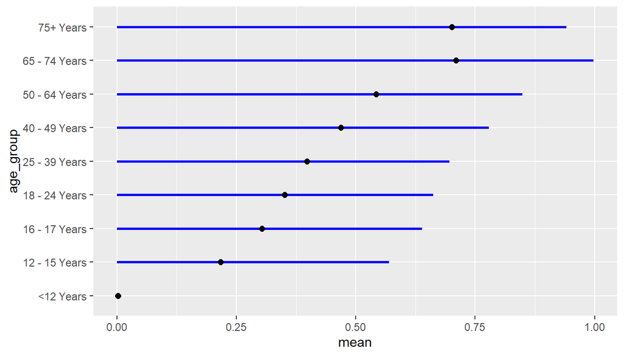

```r
df %>%
  group_by(age_group) %>%
  summarise(upper=max(prop_first_dose),
            lower=min(prop_first_dose),
            mean=mean(prop_first_dose)) %>%
  ggplot()+
  geom_linerange(aes(x=age_group, ymin=lower, ymax=upper),width=0.2, size=1, color="blue")+
  geom_point(aes(x=age_group, y=mean), size=2)+
  coord_flip()
```

This linerange shows the maximum (far right), minimum (far left) and average (the point in the middle) proportion of each age category.

## Visualization 7: Stacked bar plot

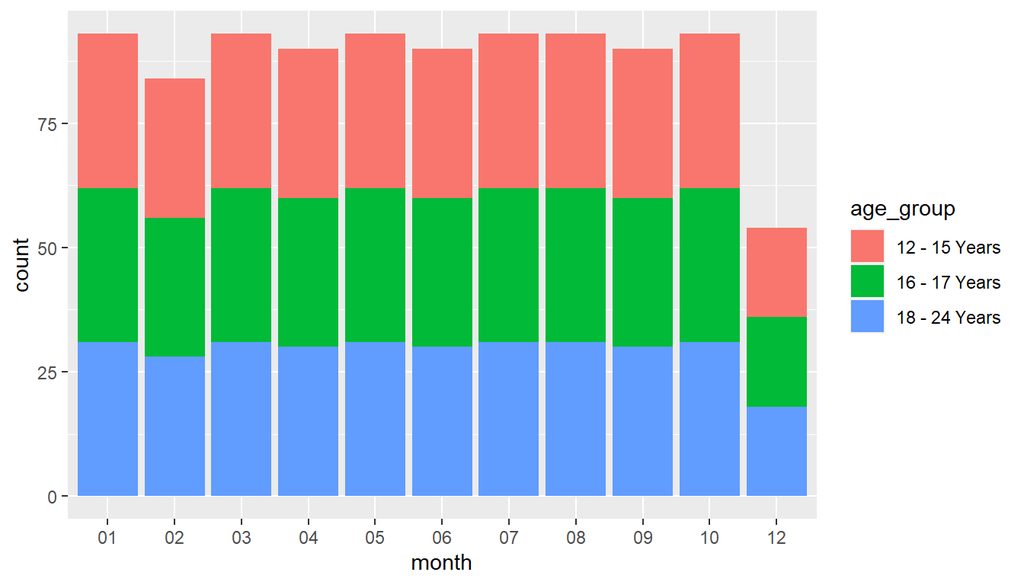

```r
df %>%
  filter(age_group %in% c("12 - 15 Years","16 - 17 Years","18 - 24 Years")) %>%
  separate(date, c("year","month","day"),"-") %>%
  ggplot(aes(fill=age_group, x=month))+
  geom_bar()
```

Here we show the number of observations in different months and for different age groups (“12 - 15 Years”,“16 - 17 Years”,“18 - 24 Years”).

## Visualization 8: Dodged bar plot

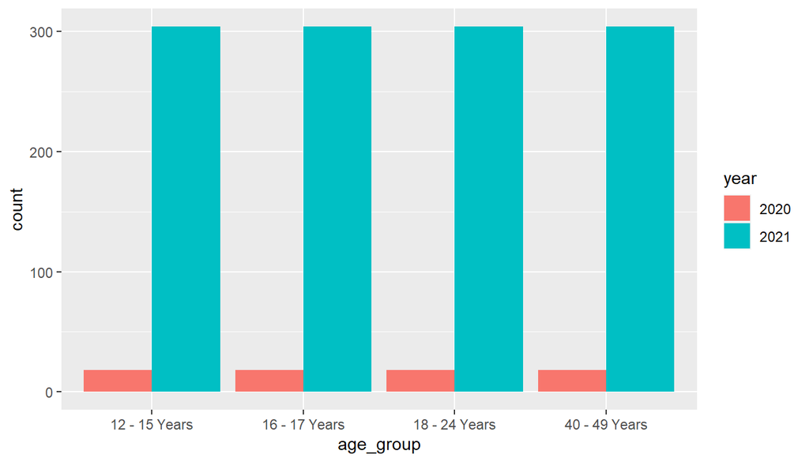

```r
df %>%
  filter(age_group %in% c("12 - 15 Years","16 - 17 Years","18 - 24 Years","40 - 49 Years")) %>%
  separate(date, c("year","month","day"),"-") %>%
  ggplot(aes(x=age_group, fill=year))+
  geom_bar(position = "dodge")
```

We show the number of observations per year (2020 and 2021) for each age group.

## Visualization 9:

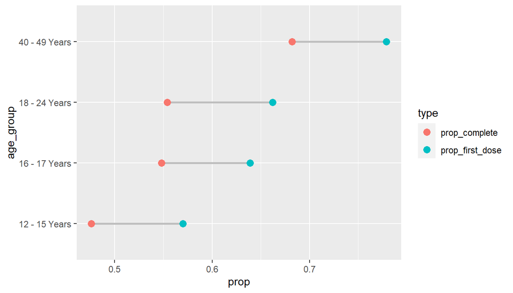

```r
df %>%
  filter(age_group %in% c("12 - 15 Years","16 - 17 Years","18 - 24 Years","40 - 49 Years"), date=="2021-10-31") %>%
  pivot_longer(cols=c("prop_first_dose", "prop_complete"),
               names_to = "type",
               values_to = "prop"
               ) %>%
  ggplot(aes(x=prop, y=age_group, group=age_group)) +
  geom_line(linewidth=1, color="gray") +
  geom_point(aes(color=type), size=3)
```

For each age group and the date 2021-10-31, we show the difference between the proportion of people who received the first dose and the proportion who received a full dose.

## Visualization 10: QQ-Plot

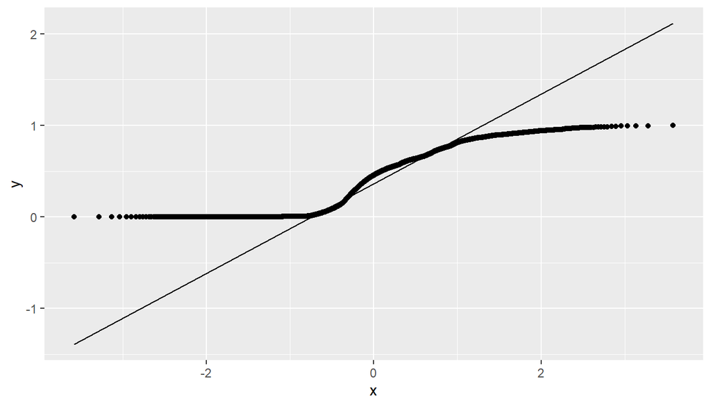

```r
df %>%
  ggplot(aes(sample=prop_first_dose))+
  geom_qq()+
  geom_qq_line()
```

This is a QQ-plot to determine whether the prop_first_dose variable follows a normal distribution. We can conclude that it does not follow a normal distribution.